# The National Endowment for the Humanities's Grantmaking to Historically Black Colleges and Universities, 1965-Present

Erik Fredner

2023-09-13

# Introduction

Of the awards granted by the National Endowment for the Humanities (NEH) to colleges and universities since its founding in 1965, what proportion have been allocated to historically Black colleges and universities (HBCUs)? And how has that allocation changed over time?

Answering these questions matters for our understanding of the past, present, and future of the NEH's grantmaking efforts. It has been frequently demonstrated by social scientists, economists, and humanists that actors both public and private have consistently underinvested in Black communities and institutions. Understanding the NEH's grantmaking history in relation to this widespread US pattern raises a broader question that we cannot answer with data alone. How should grantmakers and policymakers respond to these histories today?

## Approach

By aligning the NEH's [grant award data](https://catalog.data.gov/organization/neh-gov) with [the 2021 IPEDS Institutional Characteristics data](https://nces.ed.gov/ipeds/datacenter/data/HD2021.zip) (the most recent available), I determine whether an awarded institution is an HBCU.

I then filter the dataset to only consider other awards granted to Colleges and Universities.

Then, I output the following key numbers and figures, both in aggregate and over time:

- raw dollar amounts awarded to HBCUs and non-HBCUs
- 2022 dollar amounts adjusted using the Bureau of Labor Statistics' annualized [Consumer Price Index averages](https://data.bls.gov/timeseries/CUUR0000SA0)
- total number of grants awarded to HBCUs and non-HBCUs
- odds ratios for HBCUs and non-HBCUs to receive a grant in a given decade, given prior awardees

Code can be found on [the GitHub repository](https://github.com/erikfredner/neh-assessment) for this project and in the notebook below.

Please note that, due to the small values involved, I have chosen to visualize the data using tables, as they make it easier to see and interpret the fine gradations of change.

## Key Findings

### NEH awarded a smaller proportion of grant dollars to HBCUs in the 2020s than in 1970s

| Award Decade | HBCU Share of NEH Grant Dollars |
| --- | --- |
| 1960 | 3.9% |
| 1970 | 2.7% |
| 1980 | 2.6% |
| 1990 | 1.6% |
| 2000 | 1.8% |
| 2010 | 1.5% |
| 2020 | 1.6% |

Perhaps, even if awards today are smaller, we might expect that *more* projects from HBCUs would be funded. This is not the case either, although the proportion of awards allocated is higher than the proportion of dollars awarded. Awards to HBCUs peaked in the 1960s when they made up 3.3% of total awards, and reached their lowest point in the 1990s at about 2.1%. In the 2020s, they have received about 2.4% of total awards.

| Award Decade | HBCU Share of NEH Awards |
| --- | --- |
| 1960 | 3.3% |
| 1970 | 2.2% |
| 1980 | 3.1% |
| 1990 | 2.1% |
| 2000 | 2.8% |
| 2010 | 2.2% |
| 2020 | 2.4% |

### The odds of any HBCU receiving an award have often been substantially higher than the odds of any non-HBCU receiving an award

Because there are a significantly smaller number of HBCUs than non-HBCUs, percentages can be misleading. Odds ratios account for such variation in absolute size among groups fairly robustly. They are also easy to calculate and reason about:

$$\frac{p_1/(1-p_1)}{p_2/(1-p_2)}$$

In our case, $p_1$ represents the total number of HBCUs that received an NEH award in a given decade divided by the number of HBCUs that had *ever* received an NEH award up to that date. $p_2$ is the same as $p_1$, but for non-HBCUs. The odds ratios tells us how much more likely it is for any given HBCU to receive a grant than any given non-HBCU. In cases where the odds ratio is greater than 1, it is more likely for a given HBCU to receive an award in a decade than a given non-HBCU.

| Award Decade | HBCU/CU Odds Ratio |
| --- | --- |
| 1970 | 0.16 |
| 1980 | 5.29 |
| 1990 | 2.27 |
| 2000 | 1.62 |
| 2010 | 0.98 |
| 2020 | 1.06 |

### Summary

It is surprising but true that HBCUs have received a consistently smaller relative share of the NEH's grants to colleges and universities since the 1970s. Less surprising but no less concerning is that they have also received a lower absolute number of dollars. A caveat to this point, however, is that, in some decades, HBCUs have had a significantly higher *chance* of receiving NEH awards than other colleges or universities that had previously won an NEH grant. Howeer, in the last two decades, those chances have become relatively even. This raises the question of whether even odds are *fair* odds.

As decades of [reports by the National Endowment for the Arts](https://www.arts.gov/impact/research/publications?search_api_fulltext=survey+of+public+participation) have demonstrated, participation in artistic and humanitic activities (such as literary reading, which the NEA's reports also track) are strongly correlated with education, gender, income, and race (in roughly that order). One notion of equity policymakers could adopt would be reducing disparities in engagement with arts and humanities along these axes. NEH grantmaking could intervene in these areas, and increasing awards to HBCUs could be a part of a strategy of equity and repair.

## Limitations

- This research demonstrates that, since the 1970s, NEH awards to HBCUs have been decreasing in absolute and relative terms as compared to other colleges and universities. However, it is a question of policy and institutional priorities as to what the *appropriate* level of funding would be.
- This studies *institutional* awards, not the races or ethnicities of awardees directly. This work does not imply that the NEH's awards to HBCUs represent the totality of its giving to Black scholars or Black institutions.
- IPEDs table does *not* include open date for colleges and universities, so odds ratios are calculated based on the proportion of all Colleges and Universities (HBCU or non-HBCU) that *had ever received an award from the NEH up to that decade* as compared to the the actual number of institutions awarded in a given year. This may erroneously assume that institutions that previously won awards did not cease operations (or rename themselves) in the interim.

# Data Preparation

```python
import os
import pandas as pd
from rapidfuzz import fuzz, process, utils
```

```python
data_dir = "/Users/erik/code/neh-assessment/data"
```

```python
# get decadal xml files
xml_files = []

for root, dirs, files in os.walk(data_dir):
    for file in files:
        if file.endswith(".xml"):
            xml_files.append(os.path.join(root, file))
```

```python
# concatenate decadal xml files into one dataframe
l = list()

for file in xml_files:
    l.append(pd.read_xml(file))
```

```python
df = pd.concat(l)
```

```python
# subset df for needed columns
cols = [
    "AppNumber",
    "ApplicantType",
    "Institution",
    "OrganizationType",
    "InstPostalCode",
    "InstCountry",
    "Latitude",
    "Longitude",
    "YearAwarded",
    "Program",
    "Division",
    "AwardOutright",
    "AwardMatching",
    "SupplementAmount",
    "PrimaryDiscipline",
    "ParticipantCount",
]
```

```python
df = df[cols].copy()
```

```python
# calculate total awarded by NEH
df["total_award"] = df["AwardOutright"] + df["AwardMatching"] + df["SupplementAmount"]
```

```python
# calculate total award in 2022 dollars
cpi = pd.read_csv("/Users/erik/code/neh-assessment/data/cpi average.csv")
cpi_2022 = 292.655
awards = df[["AppNumber", "YearAwarded", "total_award"]].copy()
```

```python
awards = pd.merge(awards, cpi, left_on="YearAwarded", right_on="cpi_year", how="outer")
```

```python
awards["total_award_2022"] = round(
    awards["total_award"] * (cpi_2022 / awards["cpi_annual_avg"]), 2
)
```

```python
df = df.merge(awards[["AppNumber", "total_award_2022"]], on="AppNumber")
```

```python
# add decade
df["award_decade"] = (df["YearAwarded"] // 10) * 10
```

```python
# filter for US awardees and nonzero awards
df = df[(df["InstCountry"] == "USA") & (df["total_award"] > 0)]
```

```python
# filter for colleges and universities
orgtypes = [
    "Four-Year College",
    "University",
    "Two-Year College",
]

df = df[df["OrganizationType"].isin(orgtypes)]
```

```python
df.shape
```

```
(32538, 19)
```

```python
# import the IPEDs data
ipeds = pd.read_csv(
    "/Users/erik/code/neh-assessment/data/hd2021.csv", encoding="latin-1"
)
```

```python
# subset for needed cols
cols = [
    "UNITID",
    "INSTNM",
    "IALIAS",
    "ZIP",
    "SECTOR",
    "DEGGRANT",
    "HBCU",
    "TRIBAL",
    "LOCALE",
    "DEATHYR",
    "CARNEGIE",
    "LANDGRNT",
    "INSTSIZE",
    "LONGITUD",
    "LATITUDE",
]
```

```python
ipeds = ipeds[cols].copy()
```

```python
# tables with hbcu names + ipeds id
hbcus = ipeds[ipeds["HBCU"] == 1][["UNITID", "INSTNM"]].copy()
# table with df names + neh id
neh_insts = df[["AppNumber", "Institution"]].copy()
```

```python
def get_inst_app_numbers(df, inst):
    """Get a list of app numbers associated with an institution."""
    return df[df["Institution"] == inst]["AppNumber"].tolist()
```

```python
l = list()

for index, row in hbcus.iterrows():
    match = process.extractOne(
        row["INSTNM"],
        neh_insts["Institution"].unique(),
        scorer=fuzz.ratio,
        processor=utils.default_process,
    )
    score = match[1]
    if score >= 95:  # manually reviewed results and scores < 95 were inaccurate
        match_neh_AppNumbers = get_inst_app_numbers(neh_insts, match[0])
        for app in match_neh_AppNumbers:
            d = dict()
            d["hbcu"] = row["INSTNM"]
            d["hbcu_ipeds_UNITID"] = row["UNITID"]
            d["match"] = match[0]
            d["match_neh_AppNumber"] = app
            d["score"] = match[1]
            l.append(d)
```

```python
matches = pd.DataFrame(l)
```

```python
matches.shape
```

```
(820, 5)
```

```python
# apply matches to df
df["is_hbcu"] = df["AppNumber"].isin(matches["match_neh_AppNumber"])
```

```python
df.shape
```

```
(32538, 20)
```

# Findings

## Complete dataset, 1965-Present

```python
total_awards = df.shape[0]
print(f"Total NEH awards granted to colleges and universities: {total_awards}")
```

```
Total NEH awards granted to colleges and universities: 32538
```

```python
hbcu_awards = df[df["is_hbcu"] == True].shape[0]
print(
    f"Total NEH awards granted to historically Black colleges and universities (HBCUs): {hbcu_awards}"
)
```

```
Total NEH awards granted to historically Black colleges and universities (HBCUs): 820
```

```python
print(
    f"Awards to HBCUs as a percentage of total awards: {round((hbcu_awards / total_awards) * 100, 2)}%"
)
```

```
Awards to HBCUs as a percentage of total awards: 2.52%
```

```python
total_2022 = round(df["total_award_2022"].sum() / 1000000, 2)
print(
    f"Total NEH dollars awarded to colleges and universities in millions of 2022 dollars: ${total_2022}M"
)
```

```
Total NEH dollars awarded to colleges and universities in millions of 2022 dollars: $4696.78M
```

```python
total_hbcu_2022 = round(
    df[df["is_hbcu"] == True]["total_award_2022"].sum() / 1000000, 2
)
print(
    f"Total NEH dollars awarded to HBCUs in millions of 2022 dollars: ${total_hbcu_2022}M"
)
```

```
Total NEH dollars awarded to HBCUs in millions of 2022 dollars: $105.86M
```

```python
hbcu_total_2022 = round((total_hbcu_2022 / total_2022) * 100, 2)
print(
    f"NEH dollars awarded to HBCUs as a percentage of total NEH dollars awarded to colleges and universities: {hbcu_total_2022}%"
)
```

```
NEH dollars awarded to HBCUs as a percentage of total NEH dollars awarded to colleges and universities: 2.25%
```

## Decadal data

### Total dollars awarded

```python
cols = [
    "total_award_2022",
    "is_hbcu",
    "award_decade",
]
```

```python
award_total_decade = (
    df[["award_decade", "total_award_2022"]].groupby("award_decade").sum()
)
```

```python
# decadal NEH grants awarded relative to 1970s levels
award_total_decade / award_total_decade.loc[1970]
```

| award_decade | total_award_2022 |
| --- | --- |
| 1960 | 0.037303 |
| 1970 | 1.000000 |
| 1980 | 0.773403 |
| 1990 | 0.574490 |
| 2000 | 0.354982 |
| 2010 | 0.304168 |
| 2020 | 0.110916 |

```python
df[cols].groupby(["award_decade", "is_hbcu"]).sum()
```

| award_decade | is_hbcu | total_award_2022 |
| --- | --- | --- |
| 1960 | False | 5.335124e+07 |
|  | True | 2.175669e+06 |
| 1970 | False | 1.447683e+09 |
|  | True | 4.087252e+07 |
| 1980 | False | 1.120850e+09 |
|  | True | 3.040325e+07 |
| 1990 | False | 8.414105e+08 |
|  | True | 1.374908e+07 |
| 2000 | False | 5.190240e+08 |
|  | True | 9.386863e+06 |
| 2010 | False | 4.461081e+08 |
|  | True | 6.662556e+06 |
| 2020 | False | 1.624918e+08 |
|  | True | 2.613261e+06 |

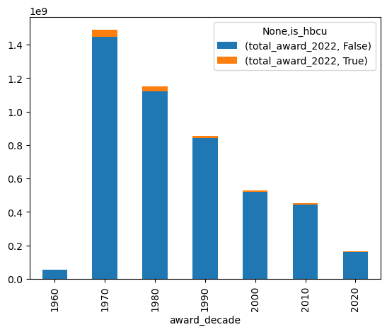

```python
df[cols].groupby(["award_decade", "is_hbcu"]).sum().unstack().plot(
    kind="bar", stacked=True
)
```

```python
df[cols].groupby(["award_decade", "is_hbcu"]).sum().divide(
    award_total_decade, level="award_decade"
)
```

| award_decade | is_hbcu | total_award_2022 |
| --- | --- | --- |
| 1960 | False | 0.960818 |
|  | True | 0.039182 |
| 1970 | False | 0.972542 |
|  | True | 0.027458 |
| 1980 | False | 0.973591 |
|  | True | 0.026409 |
| 1990 | False | 0.983922 |
|  | True | 0.016078 |
| 2000 | False | 0.982236 |
|  | True | 0.017764 |
| 2010 | False | 0.985285 |
|  | True | 0.014715 |
| 2020 | False | 0.984172 |
|  | True | 0.015828 |

```python
# make table for the write-up
t = (
    df[cols]
    .groupby(["award_decade", "is_hbcu"])
    .sum()
    .divide(award_total_decade, level="award_decade")
)
t.reset_index(inplace=True)
t = t[t["is_hbcu"] == True][["award_decade", "total_award_2022"]]
t["total_award_2022"] = t["total_award_2022"].apply(lambda x: f"{round(x*100, 1)}%")
t.columns = ["Award Decade", "HBCU Share of NEH Grant Dollars"]
t.set_index("Award Decade", inplace=True)
print(t.to_markdown())
```

```
|   Award Decade | HBCU Share of NEH Grant Dollars   |
|---------------:|:----------------------------------|
|           1960 | 3.9%                              |
|           1970 | 2.7%                              |
|           1980 | 2.6%                              |
|           1990 | 1.6%                              |
|           2000 | 1.8%                              |
|           2010 | 1.5%                              |
|           2020 | 1.6%                              |
```

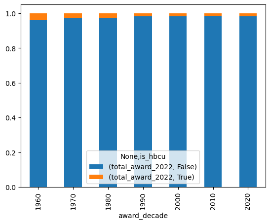

```python
df[cols].groupby(["award_decade", "is_hbcu"]).sum().divide(
    award_total_decade, level="award_decade"
).unstack().plot(kind="bar", stacked=True)
```

### Total awards granted

```python
# number of awards granted to colleges and universities by decade
awards_per_decade = df[["award_decade", "AppNumber"]].groupby("award_decade").count()
awards_per_decade
```

| award_decade | AppNumber |
| --- | --- |
| 1960 | 698 |
| 1970 | 8154 |
| 1980 | 7982 |
| 1990 | 5546 |
| 2000 | 4567 |
| 2010 | 3982 |
| 2020 | 1609 |

```python
df[["award_decade", "AppNumber", "is_hbcu"]].groupby(
    ["award_decade", "is_hbcu"]
).count()
```

| award_decade | is_hbcu | AppNumber |
| --- | --- | --- |
| 1960 | False | 675 |
|  | True | 23 |
| 1970 | False | 7974 |
|  | True | 180 |
| 1980 | False | 7734 |
|  | True | 248 |
| 1990 | False | 5429 |
|  | True | 117 |
| 2000 | False | 4440 |
|  | True | 127 |
| 2010 | False | 3895 |
|  | True | 87 |
| 2020 | False | 1571 |
|  | True | 38 |

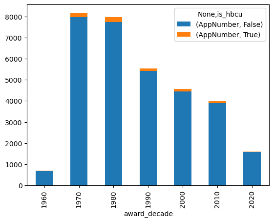

```python
# number of awards granted to colleges and universities by decade
df[["award_decade", "AppNumber", "is_hbcu"]].groupby(
    ["award_decade", "is_hbcu"]
).count().unstack().plot(kind="bar", stacked=True)
```

```python
awards_per_decade_hbcu = (
    df[["award_decade", "AppNumber", "is_hbcu"]]
    .groupby(["award_decade", "is_hbcu"])
    .count()
)
```

```python
awards_per_decade_hbcu.divide(awards_per_decade, level="award_decade")
```

| award_decade | is_hbcu | AppNumber |
| --- | --- | --- |
| 1960 | False | 0.967049 |
|  | True | 0.032951 |
| 1970 | False | 0.977925 |
|  | True | 0.022075 |
| 1980 | False | 0.968930 |
|  | True | 0.031070 |
| 1990 | False | 0.978904 |
|  | True | 0.021096 |
| 2000 | False | 0.972192 |
|  | True | 0.027808 |
| 2010 | False | 0.978152 |
|  | True | 0.021848 |
| 2020 | False | 0.976383 |
|  | True | 0.023617 |

```python
# table for write-up
t = awards_per_decade_hbcu.divide(awards_per_decade, level="award_decade")
t.reset_index(inplace=True)
t = t[t["is_hbcu"] == True][["award_decade", "AppNumber"]]
t["AppNumber"] = t["AppNumber"].apply(lambda x: f"{round(x*100, 1)}%")
t.columns = ["Award Decade", "HBCU Share of NEH Awards"]
t.set_index("Award Decade", inplace=True)
print(t.to_markdown())
```

```
|   Award Decade | HBCU Share of NEH Awards   |
|---------------:|:---------------------------|
|           1960 | 3.3%                       |
|           1970 | 2.2%                       |
|           1980 | 3.1%                       |
|           1990 | 2.1%                       |
|           2000 | 2.8%                       |
|           2010 | 2.2%                       |
|           2020 | 2.4%                       |
```

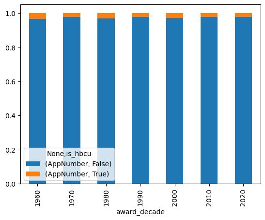

```python
awards_per_decade_hbcu.divide(awards_per_decade, level="award_decade").unstack().plot(
    kind="bar", stacked=True
)
```

## Odds ratios

```python
hbcu_unique = (
    df[df["is_hbcu"] == True]
    .groupby("award_decade")["Institution"]
    .unique()
    .reset_index()
)
cu_unique = (
    df[df["is_hbcu"] == False]
    .groupby("award_decade")["Institution"]
    .unique()
    .reset_index()
)
```

```python
def get_institution_cumsum(df):
    """
    Get the number of unique institutions per decade from a dataframe.
    Used with dataframe filtered by HBCU.
    """
    awardees = set()
    l = list()

    for index, row in df.iterrows():
        awardees.update(row["Institution"])
        d = dict()
        d["award_decade"] = row["award_decade"]
        d["unique_institutions"] = len(awardees)
        l.append(d)

    return pd.DataFrame(l)
```

```python
unique_institutions_cumsum = pd.merge(
    get_institution_cumsum(hbcu_unique),
    get_institution_cumsum(cu_unique),
    on="award_decade",
    suffixes=("_hbcu", "_cu"),
)
```

```python
unique_institutions_cumsum
```

|  | award_decade | unique_institutions_hbcu | unique_institutions_cu |
| --- | --- | --- | --- |
| 0 | 1960 | 18 | 286 |
| 1 | 1970 | 55 | 1392 |
| 2 | 1980 | 69 | 1672 |
| 3 | 1990 | 72 | 1785 |
| 4 | 2000 | 77 | 1961 |
| 5 | 2010 | 79 | 2173 |
| 6 | 2020 | 80 | 2231 |

```python
unique_institutions = (
    df[["Institution", "is_hbcu", "award_decade"]]
    .groupby(["award_decade", "is_hbcu"])
    .nunique()
)
```

```python
unique_institutions.reset_index(inplace=True)
```

```python
unique_institutions = unique_institutions.pivot(
    index="award_decade", columns="is_hbcu", values="Institution"
)
```

```python
unique_institutions
```

| is_hbcu award_decade | False | True |
| --- | --- | --- |
| 1960 | 286 | 18 |
| 1970 | 1379 | 52 |
| 1980 | 1112 | 63 |
| 1990 | 808 | 47 |
| 2000 | 938 | 46 |
| 2010 | 974 | 35 |
| 2020 | 617 | 23 |

```python
unique_institutions_cumsum.set_index("award_decade", inplace=True)
```

```python
unique_institutions_cumsum
```

| award_decade | unique_institutions_hbcu | unique_institutions_cu |
| --- | --- | --- |
| 1960 | 18 | 286 |
| 1970 | 55 | 1392 |
| 1980 | 69 | 1672 |
| 1990 | 72 | 1785 |
| 2000 | 77 | 1961 |
| 2010 | 79 | 2173 |
| 2020 | 80 | 2231 |

```python
l = list()
l.append(
    unique_institutions[True].divide(
        unique_institutions_cumsum["unique_institutions_hbcu"]
    )
)
l.append(
    unique_institutions[False].divide(
        unique_institutions_cumsum["unique_institutions_cu"]
    )
)
```

```python
ratios = pd.concat(l, axis=1)
ratios.columns = ["hbcu", "cu"]
ratios
```

| award_decade | hbcu | cu |
| --- | --- | --- |
| 1960 | 1.000000 | 1.000000 |
| 1970 | 0.945455 | 0.990661 |
| 1980 | 0.913043 | 0.665072 |
| 1990 | 0.652778 | 0.452661 |
| 2000 | 0.597403 | 0.478327 |
| 2010 | 0.443038 | 0.448228 |
| 2020 | 0.287500 | 0.276558 |

This uses the odds ratio for sequential observations as shown here:

Paul DiMaggio and Toqir Mukhtar, “Arts Participation as Cultural Capital in the United States, 1982–2002: Signs of Decline?,” Poetics, Gender, networks, and cultural capital, 32, no. 2 (April 1, 2004): 169–94, https://doi.org/10.1016/j.poetic.2004.02.005.

```python
l = list()

for index, row in ratios.iterrows():
    # div 0 warning in 1960s, where odds ratio is 1/(1-1)
    if row["award_decade"] == 1960:
        odds_ratio = 1
        l.append(odds_ratio)
        continue
    odds_ratio = (row["hbcu"] / (1 - row["hbcu"])) / (row["cu"] / (1 - row["cu"]))
    l.append(odds_ratio)
```

```python
ratios["hbcu/cu odds ratio"] = l
```

```python
ratios.reset_index(inplace=True)
ratios
```

|  | index | award_decade | hbcu | cu | hbcu/cu odds ratio |
| --- | --- | --- | --- | --- | --- |
| 0 | 0 | 1960 | 1.000000 | 1.000000 | 1.000000 |
| 1 | 1 | 1970 | 0.945455 | 0.990661 | 0.163403 |
| 2 | 2 | 1980 | 0.913043 | 0.665072 | 5.287770 |
| 3 | 3 | 1990 | 0.652778 | 0.452661 | 2.273218 |
| 4 | 4 | 2000 | 0.597403 | 0.478327 | 1.618337 |
| 5 | 5 | 2010 | 0.443038 | 0.448228 | 0.979209 |
| 6 | 6 | 2020 | 0.287500 | 0.276558 | 1.055532 |

```python
# make table for report
t = ratios[["award_decade", "hbcu/cu odds ratio"]]
t = t[t["award_decade"] > 1960]  # calculated relative to prior awards; 1960s div0
t["hbcu/cu odds ratio"] = t["hbcu/cu odds ratio"].apply(lambda x: round(x, 2))
t.columns = ["Award Decade", "HBCU/CU Odds Ratio"]
t.set_index("Award Decade", inplace=True)
print(t.to_markdown())
```

```
|   Award Decade |   HBCU/CU Odds Ratio |
|---------------:|---------------------:|
|           1970 |                 0.16 |
|           1980 |                 5.29 |
|           1990 |                 2.27 |
|           2000 |                 1.62 |
|           2010 |                 0.98 |
|           2020 |                 1.06 |
```

# AI acknowledgment

This work was completed in Microsoft's Visual Studio Code with occasional assistance from [GitHub Copilot](https://github.com/features/copilot).

Other references are linked in the document.